# Reproducible Research: Activity Data

## Load and process the data

After downloading the data set from https://d396qusza40orc.cloudfront.net/repdata%2Fdata%2Factivity.zip and setting your working directory, load the data.

```r
activityData <- read.csv('./data/activity.csv', header = TRUE, sep = ",",
  colClasses=c("numeric", "character", "numeric"))
activityData$date <- as.Date(activityData$date,"%Y-%m-%d")
```

## What is the mean total number of steps taken per day? Ignore missing values

### 1.) Calculate the total number of steps taken per day

```r
  stepsPerDay <- aggregate(steps ~ date, activityData, sum)
```

## 2.) Make a histogram of the total number of steps taken each day

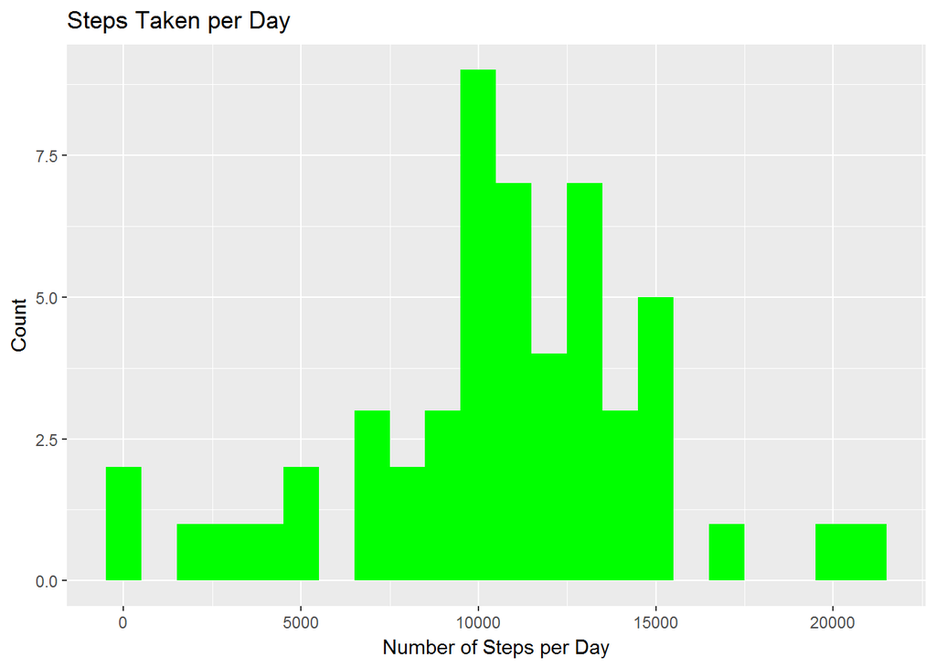

```r
  ggplot(stepsPerDay, aes(x = steps)) +
         geom_histogram(fill = "green", binwidth = 1000) +
          labs(title="Steps Taken per Day",
               x = "Number of Steps per Day", y = "Count")
```

## 3.) Calculate and report the mean and median of the total number of steps taken each day

```r
  meanStepsPerDay  <- round(mean(stepsPerDay$steps, na.rm=TRUE), 2)
  meanStepsPerDay
```

```
## [1] 10766.19
```

```r
  medianStepsPerDay <- round(median(stepsPerDay$steps, na.rm=TRUE), 2)
  medianStepsPerDay
```

```
## [1] 10765
```

The mean steps per day is 10,766.19 and the median is 10,765.

## What is the average daily activity pattern?

### 1.) Make a time series plot

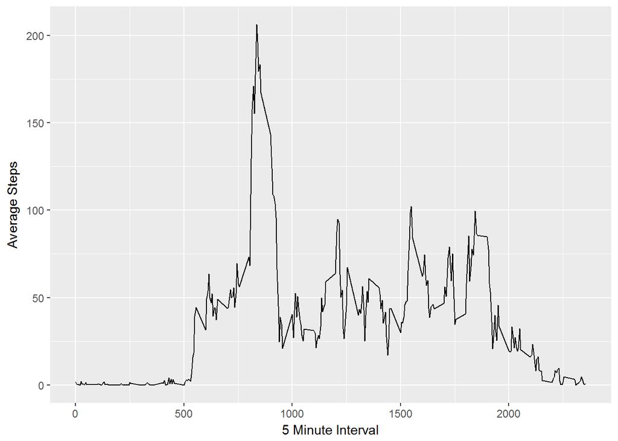

```r
stepsPerInterval <- aggregate(x=list(meanSteps=activityData$steps), by=list(interval=activityData$interval), FUN=mean, na.rm=TRUE)

ggplot(data=stepsPerInterval, aes(x=interval, y=meanSteps)) +
    geom_line() +
    xlab("5 Minute Interval") +
    ylab("Average Steps")
```

### 2.) Which 5-min interval contains the max number of steps?

```r
  maxInterval <- stepsPerInterval[which.max(
          stepsPerInterval$meanSteps),]$interval
  maxInterval
```

```
## [1] 835
```

## Impute missing values

### 1. Calculate and report the total number of missing values in the dataset

```r
  sum(is.na(activityData$steps))
```

```
## [1] 2304
```

2,304 values are missing.

### 2.) Devise a strategy for filling in all of the missing values in the dataset.

We will impute the missing values with the mean steps per interval.

### 3.) Create a new dataset that is equal to the original dataset but with the missing data filled in.

```r
  activityDataImp <- merge(x = activityData, y = stepsPerInterval, by = "interval", all.x = TRUE)
  activityDataImp$meanSteps <- round(activityDataImp$meanSteps,0)
  activityDataImp$steps[is.na( activityDataImp$steps)] <-  activityDataImp$meanSteps
  activityDataImp <- activityDataImp[,-(4)]
```

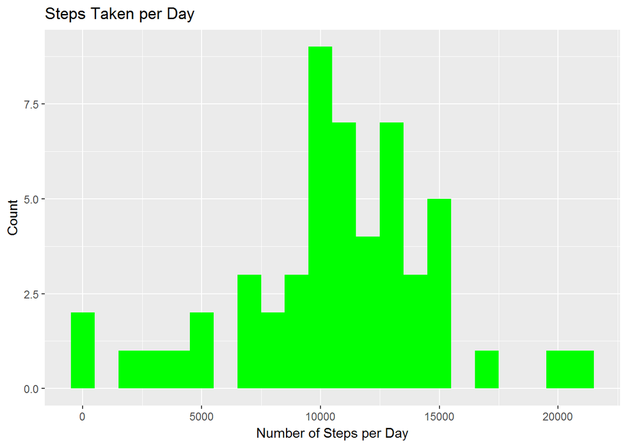

```r
  stepsPerDay2 <- aggregate(steps ~ date, activityDataImp, sum)

  ggplot(stepsPerDay, aes(x = steps)) +
         geom_histogram(fill = "green", binwidth = 1000) +
          labs(title="Steps Taken per Day",
               x = "Number of Steps per Day", y = "Count")
```

```r
  meanStepsPerDay2  <- round(mean(stepsPerDay2$steps, na.rm=TRUE), 2)
  meanStepsPerDay2
```

```
## [1] 9369.23
```

```r
  medianStepsPerDay2 <- round(median(stepsPerDay2$steps, na.rm=TRUE), 2)
  medianStepsPerDay2
```

```
## [1] 10395
```

Afterimputation, the mean steps per day is 9,369.23 and the median is 10,395.These numbers are lower than before imputing.

## Weekends and weekdays

### 1.) Create a new factor variable in the dataset with two levels - “weekday” and “weekend” indicating whether a given date is a weekday or weekend day.

```r
  activityDataImp$day <- weekdays(as.Date(activityDataImp$date))
  activityDataImp$wknd <- ifelse(activityDataImp$day %in% c("Saturday", "Sunday"), "weekend", "weekday")

  stepsPerDay2$day <- weekdays(as.Date(stepsPerDay2$date))
  stepsPerDay2$wknd <- ifelse(stepsPerDay2$day %in% c("Saturday", "Sunday"), "weekend", "weekday")
```

## 2.) Make a panel plot containing a time series plot

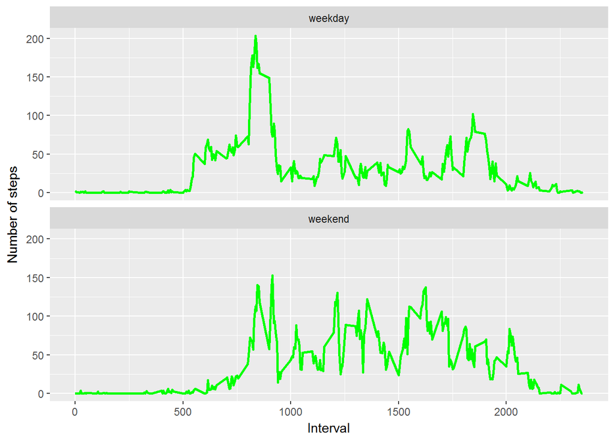

```r
  activityDataImp2 <- aggregate(steps ~ interval + wknd, data=activityDataImp, mean)

  ggplot(activityDataImp2, aes(x=interval, y=steps)) +
          geom_line(color="green", size=1) +
          facet_wrap(~ wknd, nrow=2, ncol=1) +
          labs(x="Interval", y="Number of steps")
```